# Project 2: Data Mining, Classification, Prediction

SDS322E

# Mining, Classification, Prediction

## Lingyu Yan ly4423

### Introduction

Affairs happen more and more in marriage currently, and there are also examples of this around my parents’ friends. Therefore, I am interested in reasons contribute to affairs. The dataset are built-in (R) dataset. There are nine variables: affairs, age, gender, years of married, have children or not, number of religiousness, education levels in year, occupation according to Hollingshead classification, and self rating of marriage. For this data, I would like to focus on if children are in the marriage, so the “gender” variable and serial numbers of obersvations will be deleted. There are totally 601 observations and also 601 observations for binary variable “children”.

```r
library(tidyverse)
library(tidyr)
affair <- read_csv("~/Downloads/Affairs.csv")
affair <- affair %>% select(-1,-gender) %>% drop_na()
affair
```

```
## # A tibble: 601 × 8
##    affairs   age yearsmarried children religiousness education occupation rating
##      <dbl> <dbl>        <dbl> <chr>            <dbl>     <dbl>      <dbl>  <dbl>
##  1       0    37        10    no                   3        18          7      4
##  2       0    27         4    no                   4        14          6      4
##  3       0    32        15    yes                  1        12          1      4
##  4       0    57        15    yes                  5        18          6      5
##  5       0    22         0.75 no                   2        17          6      3
##  6       0    32         1.5  no                   2        17          5      5
##  7       0    22         0.75 no                   2        12          1      3
##  8       0    57        15    yes                  2        14          4      4
##  9       0    32        15    yes                  4        16          1      2
## 10       0    22         1.5  no                   4        14          4      5
## # … with 591 more rows
```

### Cluster Analysis

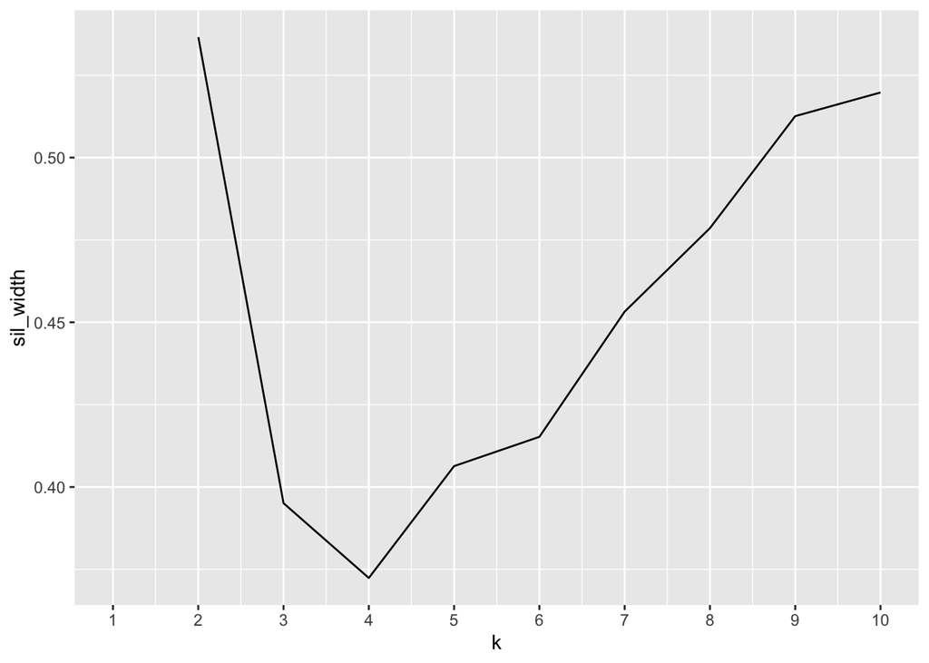

```r
library(cluster)
library(GGally)
pam_dat <- affair%>%select(affairs,age,yearsmarried)
sil_width <- vector()
for(i in 2:10){
    pam_fit <- pam(pam_dat, k = i)
    sil_width[i] <- pam_fit$silinfo$avg.width
}
ggplot()+geom_line(aes(x=1:10,y=sil_width))+scale_x_continuous(name="k",breaks=1:10)
```

```r
set.seed(332)
pam1 <- pam_dat %>% pam(2)
pam1
```

```
## Medoids:
##       ID affairs age yearsmarried
## [1,] 470       1  42           15
## [2,]   2       0  27            4
## Clustering vector:
##   [1] 1 2 1 1 2 2 2 1 1 2 1 2 1 2 2 1 1 2 2 2 2 2 2 2 2 2 2 1 2 2 1 2 2 1 2 2 1
##  [38] 2 2 2 2 1 2 2 2 2 2 1 2 1 2 2 2 2 2 1 2 1 2 2 1 1 2 2 2 1 1 1 2 2 2 2 2 1
##  [75] 1 2 2 2 2 1 2 1 2 1 2 2 1 2 2 1 1 1 1 1 2 1 1 1 1 1
##  [ reached getOption("max.print") -- omitted 501 entries ]
## Objective function:
##    build     swap
## 7.456116 6.104768
##
## Available components:
##  [1] "medoids"    "id.med"     "clustering" "objective"  "isolation"
##  [6] "clusinfo"   "silinfo"    "diss"       "call"       "data"
```

[figure not shown]

```r
plot(pam1, which=2)
```

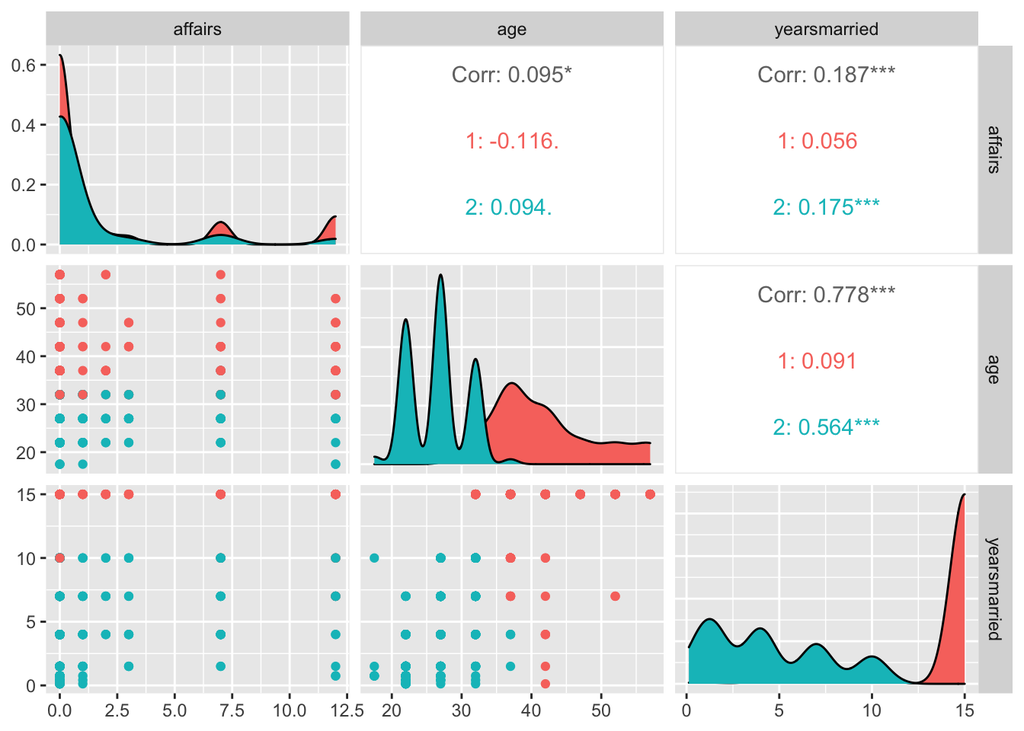

```r
affair %>% mutate(cluster=as.factor(pam1$clustering))%>%ggpairs(columns=c(1,2,3),aes(color=cluster))
```

Among these three variables, affair and age have the least correlation with 0.095. Age and years of married have the strongest correlation with 0.778. The average silhouette width is 0.54 which means that a reasonable structure has been found and the data point is cohesive within the cluster.

### Dimensionality Reduction with PCA

```r
# PCA code here
affair_nums <- affair %>% select_if(is.numeric) %>% scale
rownames(affair_nums) <- affair$Name
affair_pca <- princomp(affair_nums)
names(affair_pca)
```

```
## [1] "sdev"     "loadings" "center"   "scale"    "n.obs"    "scores"   "call"
```

```r
summary(affair_pca, loadings=T)
```

```
## Importance of components:
##                           Comp.1    Comp.2    Comp.3    Comp.4     Comp.5
## Standard deviation     1.4327541 1.2434202 1.1291783 0.8706692 0.83236317
## Proportion of Variance 0.2937437 0.2212387 0.1824527 0.1084755 0.09914045
## Cumulative Proportion  0.2937437 0.5149823 0.6974350 0.8059105 0.90505092
##                            Comp.6     Comp.7
## Standard deviation     0.67678263 0.45332428
## Proportion of Variance 0.06554259 0.02940649
## Cumulative Proportion  0.97059351 1.00000000
##
## Loadings:
##               Comp.1 Comp.2 Comp.3 Comp.4 Comp.5 Comp.6 Comp.7
## affairs        0.225  0.115  0.626  0.157  0.715
## age            0.616        -0.169 -0.318                0.693
## yearsmarried   0.615  0.155 -0.127 -0.283               -0.706
## religiousness  0.188  0.127 -0.603  0.707  0.288
## education      0.168 -0.673                       0.716
## occupation     0.207 -0.641  0.112  0.225        -0.681 -0.103
## rating        -0.292 -0.286 -0.431 -0.489  0.625 -0.133
```

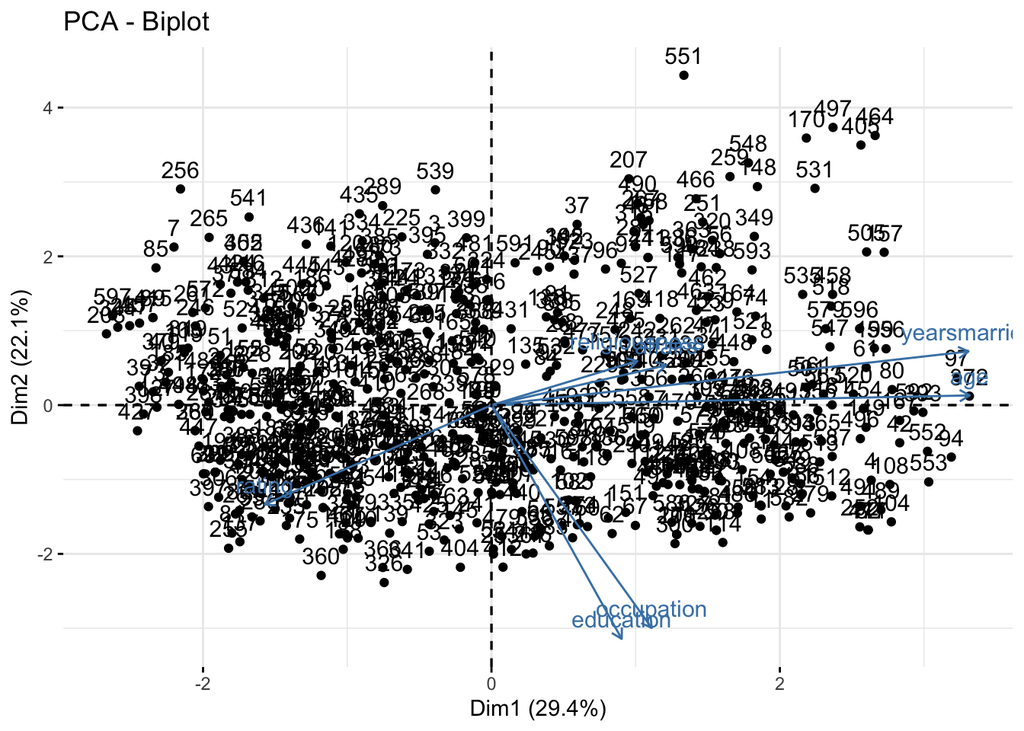

```r
library(factoextra)
fviz_pca_biplot(affair_pca)
```

### Linear Classifier

```r
affair <- affair %>% mutate(children=ifelse(children=="yes", 1, 0))
fit <- glm(children ~ . , data=affair, family="binomial")
score <- predict(fit, type="response")
class_diag(score, affair$children, positive=1)
```

```
##           acc   sens   spec    ppv     f1     ba    auc
## Metrics 0.822 0.8674 0.7076 0.8818 0.8746 0.7875 0.8838
```

```r
table(truth = affair$children, predictions = score>.5)
```

```
##      predictions
## truth FALSE TRUE
##     0   121   50
##     1    57  373
```

```r
set.seed(322)
k=10
data<-sample_frac(affair)
folds <- rep(1:k, length.out=nrow(data))
diags<-NULL
i=1
for(i in 1:k){
train<-data[folds!=i,]
test<-data[folds==i,]
truth<-test$children
fit <- glm(children ~ . , data=train, family="binomial")
probs <- predict(fit, newdata=test, type="response")
diags <- rbind(diags,class_diag(probs,truth, positive=1)) }
summarize_all(diags,mean)
```

```
##       acc    sens    spec     ppv     f1      ba     auc
## 1 0.81368 0.86577 0.68792 0.87426 0.8683 0.77684 0.88037
```

The model performs outstandingly per CV AUC value of 0.8804. AUC dropped a little bit in CV compared to AUC in logistic regression of 0.8838. This is a sign of overfitting a tiny bit.

### Non-Parametric Classifier

```r
library(caret)
knn_fit <- knn3(children ~ . , data=affair)
knn_fit
```

```
## 5-nearest neighbor model
## Training set outcome distribution:
##    Min. 1st Qu.  Median    Mean 3rd Qu.    Max.
##  0.0000  0.0000  1.0000  0.7155  1.0000  1.0000
```

```r
prob_knn <- predict(knn_fit, newdata=affair)[,2]
class_diag(prob_knn, affair$children, positive=1)
```

```
##            acc   sens   spec    ppv     f1     ba    auc
## Metrics 0.8552 0.9233 0.6842 0.8803 0.9012 0.8037 0.9281
```

```r
# cross-validation of np classifier here
set.seed(322)
k=10
data<-sample_frac(affair)
folds <- rep(1:k, length.out=nrow(data))
diags<-NULL
i=1
for(i in 1:k){
train<-data[folds!=i,]
test<-data[folds==i,]
truth<-test$children
fit <- knn3(children ~ ., data=train)
probs <- predict(fit, newdata=test)[,2]
diags<-rbind(diags,class_diag(probs,truth, positive=1)) }
summarize_all(diags,mean)
```

```
##       acc    sens    spec    ppv      f1      ba     auc
## 1 0.81705 0.89292 0.64954 0.8615 0.87378 0.77123 0.85216
```

The model performs outstandingly per CV AUC value of 0.8522. AUC dropped in CV compared to AUC in knn of 0.9281 This is a sign of overfitting. Logistic regression performed better in cross-validation.

### Regression/Numeric Prediction

```r
fit <- lm(children~ ., data=affair)
yhat <- predict(fit)
mean((affair$children-yhat)^2)
```

```
## [1] 0.1327467
```

```r
set.seed(1234)
k=5
data <- affair[sample(nrow(affair)),]
folds <- cut(seq(1:nrow(affair)),breaks=k,labels=F)
diags<-NULL
for(i in 1:k){
  train <- data[folds!=i,]
  test <- data[folds==i,]
  fit <- lm(children~ .,data=train)
  yhat <- predict(fit,newdata=test)
  diags<-mean((test$children-yhat)^2)
}
mean(diags)
```

```
## [1] 0.1161984
```

### Python

```r
library(reticulate)
use_python("/usr/bin/python3", required=F)
hi <- "Hello"
cat(c(hi,py$hi))
```

```
## Hello
```

```python
hi="world"
print(r.hi,hi)
```

```
## ('Hello', 'world')
```

We use reticulate package to let R and Python plat together. Then we access R-defined objects with r in Python code chunk. Finally, we can access Python-defined objects with py$.